# Introduction to Numpy

## Agenda

In this lab we are going to learn basics of numpy array:-

1. What is an array?
2. Various method to create an array
3. Array Attributes and Methods

## Introduction

Datasets can come from a wide range of sources and a wide range of formats, including collections of documents, collections of images, collections of sound clips, collections of numerical measurements, or nearly anything else. Despite this apparent heterogeneity, it will help us to think of all data fundamentally as arrays of numbers.

For example, a grayscale image can be thought of as simply two-dimensional arrays of numbers representing pixel brightness across the area. Sound clips can be thought of as one-dimensional arrays of intensity versus time.

No matter what the data are, the first step in making them analyzable will be to transform them into arrays of numbers.

For this reason, efficient storage and manipulation of numerical arrays is absolutely fundamental to the process of doing data science.Specialized tools that Python has for handling such numerical arrays: the NumPy package and the Pandas package

Numerical Python, or "Numpy" for short, is a foundational package on which many of the most common data science packages are built. Numpy provides us with high performance multi-dimensional arrays which we can use as vectors or matrices. It is a Python library that provides a multidimensional array object and an assortment of routines for fast operations on arrays, including mathematical, logical, shape manipulation, sorting, basic linear algebra, basic statistical operations and much more.

Besides, NumPy is an open source Python library that’s used in almost every field of science and engineering. It’s the universal standard for working with numerical data in Python. NumPy users include everyone from beginning coders to experienced researchers doing state-of-the-art scientific and industrial research and development. NumPy is also the basis of extensively used libraries such as Pandas, SciPy, Matplotlib, scikit-learn and most other data science and scientific Python packages.

NumPy arrays form the core of nearly the entire ecosystem of data science tools in Python, so time spent learning to use NumPy effectively will be valuable no matter what aspect of data science interests you.

**Why use NumPy?**

NumPy arrays are faster and more compact than Python lists. An array consumes less memory and is convenient to use. NumPy uses much less memory to store data and it provides a mechanism of specifying the data types. This allows the code to be optimized even further.

## Installing & Importing NumPy

Once you've installed NumPy you can import it as a library:

```python
# !pip install numpy
```

```python
import numpy as np

print(np.__version__) #Check Version
```

```
1.19.5
```

**Tip:** if your autocomplete is not working, try this:

```
%config Completer.use_jedi = False
```

## What is an array?

An array is a grid of values and it contains information about the raw data. It has a grid of elements that can be indexed in various ways. The elements are all of the same type, referred to as the array dtype.

- The rank of an array is the number of dimensions.
- The shape of the array is a tuple of integers giving the size of the array along each dimension.

A vector is an array with a single dimension (there’s no difference between row and column vectors), while a matrix refers to an array with two dimensions. For 3-D or higher dimensional arrays, the term tensor is also commonly used. An N-dimensional array is simply an array with any number of dimensions.

# Numpy Arrays

NumPy arrays are the main way we will use Numpy throughout the course. Numpy arrays essentially come in two flavors: vectors and matrices. Vectors are strictly 1-d arrays and matrices are 2-d (but you should note a matrix can still have only one row or one column).

Let's begin our introduction by exploring how to create NumPy arrays.

## Creating NumPy Arrays

```python
np.array([1,2,3])   # 1-dimensional array
```

```
array([1, 2, 3])
```

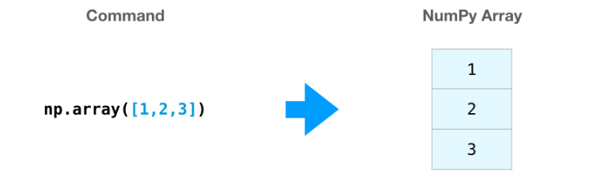

```python
np.array([[1, 2], [3, 4]])  # 2-dimensional array
```

```
array([[1, 2],
       [3, 4]])
```

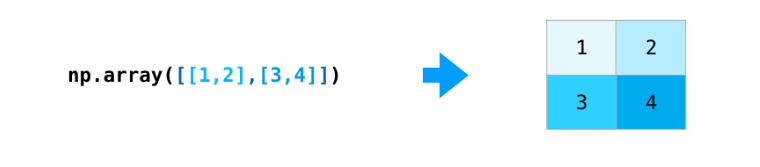

```python
np.array([ [[1,2],[3,4]],
           [[5,6],[7,8]] ])   # 3-dimensional array
```

```
array([[[1, 2],
        [3, 4]],

       [[5, 6],
        [7, 8]]])
```

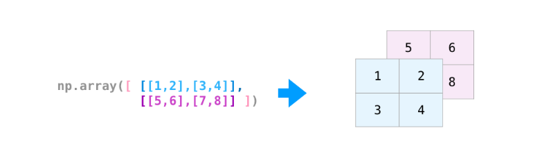

```python
ar_1D = np.array([7,2,9,10])
print(ar_1D)
```

```
[ 7  2  9 10]
```

```python
ar_2D = np.array([[7,2,9,10],[2,5,3,8]])
print(ar_2D)
```

```
[[ 7  2  9 10]
 [ 2  5  3  8]]
```

```python
ar_3D = np.array([[[7,2,9,10],[2,5,3,8]],[[1,4,7,2],[9,7,1,3]]])
```

```python
ar_3D = np.array([
                    [[7,2,9,10],[2,5,3,8]],
                    [[7,2,9,10],[2,5,3,8]]
                 ])
```

```python
print(ar_3D)
```

```
[[[ 7  2  9 10]
  [ 2  5  3  8]]

 [[ 7  2  9 10]
  [ 2  5  3  8]]]
```

```python
print(ar_3D.shape)
```

```
(2, 2, 4)
```

```python
print(ar_3D.ndim)
```

```
3
```

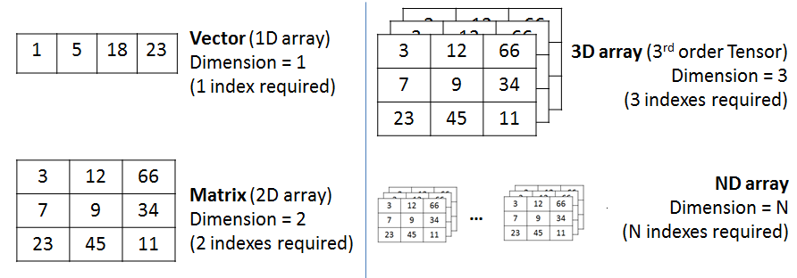

```python
ar_1D = np.array([1,5,18,23])
print(ar_1D)
```

```
[ 1  5 18 23]
```

```python
ar_2D = np.array([[3,12,66],[7,9,34],[23,45,11]])
print(ar_2D)
```

```
[[ 3 12 66]
 [ 7  9 34]
 [23 45 11]]
```

```python
ar_3D = np.array([
                    [[3,12,66],[7,9,34],[23,45,11]],
                    [[3,12,66],[7,9,34],[23,45,11]],
                    [[3,12,66],[7,9,34],[23,45,11]]
                ])
```

```python
print(ar_3D)
```

```
[[[ 3 12 66]
  [ 7  9 34]
  [23 45 11]]

 [[ 3 12 66]
  [ 7  9 34]
  [23 45 11]]

 [[ 3 12 66]
  [ 7  9 34]
  [23 45 11]]]
```

```python
print(ar_3D.shape)
```

```
(3, 3, 3)
```

```python
print(ar_3D.ndim)
```

```
3
```

```python
ar_3D = np.array([[
          [1, 4, 7],
          [2, 9, 7],
          [1, 3, 0],
          [9, 6, 9]],

         [[2, 3, 4],
          [7, 9, 5],
          [0, 3, 2],
          [9, 6, 8]]])

print(ar_3D)
```

```
[[[1 4 7]
  [2 9 7]
  [1 3 0]
  [9 6 9]]

 [[2 3 4]
  [7 9 5]
  [0 3 2]
  [9 6 8]]]
```

```python
print(ar_3D.shape)
```

```
(2, 4, 3)
```

```python
print(ar_3D.ndim)
```

```
3
```

### From a Python List

We can create an array by directly converting a list or list of lists:

```python
my_list1 = [1.5,2,3]
my_list1
```

```
[1.5, 2, 3]
```

```python
my_list2 = [5,6,8]
my_list2
```

```
[5, 6, 8]
```

```python
np.array(my_list2)
```

```
array([5, 6, 8])
```

```python
np.array(my_list1) #Convert this list into array...1d array is vector
```

```
array([1.5, 2. , 3. ])
```

```python
np.array([my_list1,my_list2])
```

```
array([[1.5, 2. , 3. ],
       [5. , 6. , 8. ]])
```

```python
my_matrix = [[1,2,3],[4,5,6],[7,8,9]]
my_matrix
```

```
[[1, 2, 3], [4, 5, 6], [7, 8, 9]]
```

```python
np.array(my_matrix)
```

```
array([[1, 2, 3],
       [4, 5, 6],
       [7, 8, 9]])
```

## What’s the difference between a Python list and a NumPy array?

- In some ways, NumPy arrays are like Python’s built-in list type, but NumPy arrays provide much more efficient storage and data operations and manipulating as the arrays grow larger in size.
- NumPy gives you an enormous range of fast and efficient ways of creating arrays and manipulating numerical data inside them.
- While a Python list can contain different data types within a single list, all of the elements in a NumPy array should be homogeneous. The mathematical operations that are meant to be performed on arrays would be extremely inefficient if the arrays weren’t homogeneous.

## Built-in Methods

There are lots of built-in ways to generate Arrays

### arange

Return evenly spaced values within a given interval.

```python
np.arange(0,10)
```

```
array([0, 1, 2, 3, 4, 5, 6, 7, 8, 9])
```

```python
np.arange(0,11,2) #(start,stop,interval/steps) if interval not specified it'll be 1 by default
```

```
array([ 0,  2,  4,  6,  8, 10])
```

### zeros and ones

Generate arrays of zeros or ones

```python
np.zeros(3) # (rows)
```

```
array([0., 0., 0.])
```

```python
np.zeros((5,5)) #((rows,cloumns))
```

```
array([[0., 0., 0., 0., 0.],
       [0., 0., 0., 0., 0.],
       [0., 0., 0., 0., 0.],
       [0., 0., 0., 0., 0.],
       [0., 0., 0., 0., 0.]])
```

```python
np.ones(3)
```

```
array([1., 1., 1.])
```

```python
np.ones((3,3))
```

```
array([[1., 1., 1.],
       [1., 1., 1.],
       [1., 1., 1.]])
```

The `full()` function return a new array of given shape and type, filled with `fill_value`.

```python
np.full((3, 3), 10) #((rows,columns), fill_value)
```

```
array([[10, 10, 10],
       [10, 10, 10],
       [10, 10, 10]])
```

### linspace

Return evenly spaced numbers over a specified interval.

```python
np.linspace(0,10,5) #(start,stop,number of observations) , no n-1**
```

```
array([ 0. ,  2.5,  5. ,  7.5, 10. ])
```

```python
np.linspace(0,10,50)
```

```
array([ 0.        ,  0.20408163,  0.40816327,  0.6122449 ,  0.81632653,
        1.02040816,  1.2244898 ,  1.42857143,  1.63265306,  1.83673469,
        2.04081633,  2.24489796,  2.44897959,  2.65306122,  2.85714286,
        3.06122449,  3.26530612,  3.46938776,  3.67346939,  3.87755102,
        4.08163265,  4.28571429,  4.48979592,  4.69387755,  4.89795918,
        5.10204082,  5.30612245,  5.51020408,  5.71428571,  5.91836735,
        6.12244898,  6.32653061,  6.53061224,  6.73469388,  6.93877551,
        7.14285714,  7.34693878,  7.55102041,  7.75510204,  7.95918367,
        8.16326531,  8.36734694,  8.57142857,  8.7755102 ,  8.97959184,
        9.18367347,  9.3877551 ,  9.59183673,  9.79591837, 10.        ])
```

## eye

Creates an identity matrix

```python
np.eye(8) #(number of daigonal elements or ones)
```

```
array([[1., 0., 0., 0., 0., 0., 0., 0.],
       [0., 1., 0., 0., 0., 0., 0., 0.],
       [0., 0., 1., 0., 0., 0., 0., 0.],
       [0., 0., 0., 1., 0., 0., 0., 0.],
       [0., 0., 0., 0., 1., 0., 0., 0.],
       [0., 0., 0., 0., 0., 1., 0., 0.],
       [0., 0., 0., 0., 0., 0., 1., 0.],
       [0., 0., 0., 0., 0., 0., 0., 1.]])
```

## Random

Numpy also has lots of ways to create random number arrays:

### rand

Create an array of the given shape and populate it with random values from a uniform distribution over `[0, 1)` i.e., equally probable values between the interval [0,1].

```python
np.random.rand(2) #(rows,cloumns)
```

```
array([0.46809351, 0.75982717])
```

```python
np.random.rand(2,3) #rand deals with float numbers from 0 to 1.
```

```
array([[0.36306245, 0.37504788, 0.26097312],
       [0.0539447 , 0.47492695, 0.89995865]])
```

```python
np.random.rand(5,5)
```

```
array([[0.36602143, 0.58031415, 0.66963117, 0.83485473, 0.0986444 ],
       [0.73748485, 0.99212311, 0.42236192, 0.27683216, 0.85115348],
       [0.52750051, 0.08954274, 0.49629858, 0.64371124, 0.18052286],
       [0.62951426, 0.14370995, 0.65444993, 0.24377598, 0.32054332],
       [0.0039603 , 0.15279987, 0.15844345, 0.7013727 , 0.81691726]])
```

### randn

Return a sample (or samples) from the "standard normal" distribution. Unlike `rand` which is uniform. In simple words, where most of the random values are centred around 0.

```python
np.random.randn(2) #(rows,cloumns)
```

```
array([-1.7298424 , -0.15340107])
```

```python
np.random.randn(5,5) #randn deals with values from -inf to +inf.
```

```
array([[-0.36836253,  0.53548534, -1.71923365,  1.24941372, -0.84796567],
       [ 1.26527338, -0.63815135, -0.02443349,  0.49999447, -0.21507465],
       [ 1.68333171, -0.34503055, -0.96393853,  0.32520268,  1.02102495],
       [-0.61188994, -0.61898247, -1.33544985, -0.26583741,  1.28220271],
       [ 0.09382112, -0.25979358,  0.77253535,  0.07494856,  1.20705732]])
```

### randint

Return random integers from `low` (inclusive) to `high` (exclusive).

```python
np.random.randint(1,100) #by default number of obs is 1
```

```
62
```

```python
np.random.randint(1,100,10) #(start,stop,number of observations)
```

```
array([65, 71, 65, 30, 33, 89, 26, 29, 77, 68])
```

```python
np.random.randint(5,500,80)
```

```
array([446, 217, 472, 467, 311, 387, 197,  93, 236, 202, 152,  42, 481,
       230, 344,  29, 181, 224, 491, 306, 473, 199,   5, 496, 341, 307,
        96,  41, 255, 210, 132,  48, 291, 473, 418, 111, 208, 494, 163,
       316, 107, 433, 461, 433, 104, 364, 171, 208, 411, 114, 405, 214,
       246, 325, 457, 398, 409, 123, 324, 261, 315, 355, 404, 151,  59,
       288, 393, 347,  85, 490, 477, 357, 421, 474,   6, 490, 367, 428,
       203,  14])
```

## Array Attributes and Methods

Let's discuss some useful attributes and methods or an array:

```python
# np.arange?
```

```python
arr = np.arange(25) #(end point, which is not inclusive)
```

```python
arr
```

```
array([ 0,  1,  2,  3,  4,  5,  6,  7,  8,  9, 10, 11, 12, 13, 14, 15, 16,
       17, 18, 19, 20, 21, 22, 23, 24])
```

## Reshape

Returns an array containing the same data with a new shape.

```python
arr
```

```
array([ 0,  1,  2,  3,  4,  5,  6,  7,  8,  9, 10, 11, 12, 13, 14, 15, 16,
       17, 18, 19, 20, 21, 22, 23, 24])
```

```python
arr.shape #(25,), i.e., a vector
```

```
(25,)
```

```python
mat = arr.reshape(5,5) #(rows,cloumns)
mat
```

```
array([[ 0,  1,  2,  3,  4],
       [ 5,  6,  7,  8,  9],
       [10, 11, 12, 13, 14],
       [15, 16, 17, 18, 19],
       [20, 21, 22, 23, 24]])
```

```python
mat.shape
```

```
(5, 5)
```

```python
arr1 = np.arange(0,15)
arr1
```

```
array([ 0,  1,  2,  3,  4,  5,  6,  7,  8,  9, 10, 11, 12, 13, 14])
```

```python
arr1.shape
```

```
(15,)
```

```python
arr1.reshape(5,3)
```

```
array([[ 0,  1,  2],
       [ 3,  4,  5],
       [ 6,  7,  8],
       [ 9, 10, 11],
       [12, 13, 14]])
```

```python
arr1.reshape(2,8)
```

```
---------------------------------------------------------------------------
ValueError                                Traceback (most recent call last)
<ipython-input-57-46f8e4dcbd4f> in <module>
----> 1 arr1.reshape(2,8)

ValueError: cannot reshape array of size 15 into shape (2,8)
```

**Exercise : Try these :**

```python
# arr1.reshape(5,3)
# arr1.reshape(3,5)
# arr1.reshape(15,1)
# arr1.reshape(1,15)
```

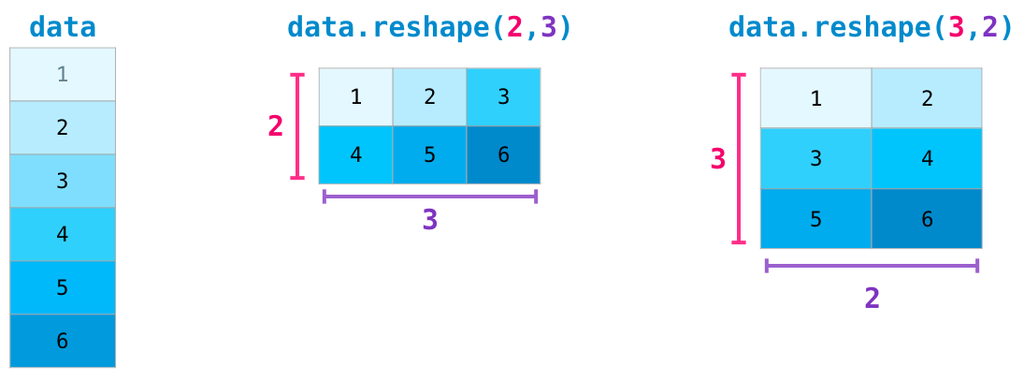

```python
data = np.arange(1,7)
data
```

```
array([1, 2, 3, 4, 5, 6])
```

```python
data.shape
```

```
(6,)
```

```python
data.reshape(2,3)
```

```
array([[1, 2, 3],
       [4, 5, 6]])
```

```python
data.reshape(3,2)
```

```
array([[1, 2],
       [3, 4],
       [5, 6]])
```

```python
narr = np.arange(1, 10).reshape((3, 3)) # creation and reshaping in a single line of code
print(narr)
```

```
[[1 2 3]
 [4 5 6]
 [7 8 9]]
```

```python
a = np.arange(1,11).reshape((2,5))
a
```

```
array([[ 1,  2,  3,  4,  5],
       [ 6,  7,  8,  9, 10]])
```

```python
b = a.reshape((5,2))
b
```

```
array([[ 1,  2],
       [ 3,  4],
       [ 5,  6],
       [ 7,  8],
       [ 9, 10]])
```

### max, min, argmax, argmin

These are useful methods for finding max or min values. Or to find their index locations using argmin or argmax

```python
ranarr1 = np.random.randint(10,80,20)
ranarr1
```

```
array([30, 50, 42, 68, 13, 50, 32, 43, 79, 33, 17, 37, 19, 30, 23, 52, 60,
       76, 68, 28])
```

```python
ranarr1.max()
```

```
79
```

```python
ranarr1.argmax()
```

```
8
```

```python
ranarr1.min()
```

```
13
```

```python
ranarr1.argmin()
```

```
4
```

## Shape

Shape is an attribute that arrays have (not a method):

```python
arr
```

```
array([ 0,  1,  2,  3,  4,  5,  6,  7,  8,  9, 10, 11, 12, 13, 14, 15, 16,
       17, 18, 19, 20, 21, 22, 23, 24])
```

```python
# Vector
arr.shape
```

```
(25,)
```

```python
# Notice the two sets of brackets
arr.reshape(1,25)
```

```
array([[ 0,  1,  2,  3,  4,  5,  6,  7,  8,  9, 10, 11, 12, 13, 14, 15,
        16, 17, 18, 19, 20, 21, 22, 23, 24]])
```

```python
arr.reshape(5,5).shape
```

```
(5, 5)
```

```python
arr.reshape(25,1)
```

```
array([[ 0],
       [ 1],
       [ 2],
       [ 3],
       [ 4],
       [ 5],
       [ 6],
       [ 7],
       [ 8],
       [ 9],
       [10],
       [11],
       [12],
       [13],
       [14],
       [15],
       [16],
       [17],
       [18],
       [19],
       [20],
       [21],
       [22],
       [23],
       [24]])
```

```python
arr.reshape(25,1).shape
```

```
(25, 1)
```

### dtype

You can also grab the data type of the object in the array:

```python
arr
```

```
array([ 0,  1,  2,  3,  4,  5,  6,  7,  8,  9, 10, 11, 12, 13, 14, 15, 16,
       17, 18, 19, 20, 21, 22, 23, 24])
```

```python
arr.dtype
```

```
dtype('int64')
```

```python
ranarr3=np.random.rand(5,4)
ranarr3
```

```
array([[0.3629619 , 0.91987804, 0.19164978, 0.37217716],
       [0.21834032, 0.90204015, 0.9609331 , 0.55652705],
       [0.87461854, 0.26722992, 0.73308532, 0.23745251],
       [0.72916316, 0.81169206, 0.18882308, 0.46370837],
       [0.30225465, 0.74085607, 0.76445444, 0.10994645]])
```

```python
ranarr3.dtype
```

```
dtype('float64')
```